# Practical Machine Learning Project

François Reynald

10 janvier 2015

# Executive summary

In this project we analyze the data measured by devices during barbell lifts to create a model able to predict the manner in which the exercice was done. The data for this project come from this source: http://groupware.les.inf.puc-rio.br/har. We show that we can create a model from the data that yields very accurate predictions.

# Download training data

```r
if(!file.exists("pml-training.csv")) {
  fileUrl <- "https://d396qusza40orc.cloudfront.net/predmachlearn/pml-training.csv"
  download.file(fileUrl, destfile="pml-training.csv",method="curl")
}
if (!exists("rawtraining"))
  rawtraining <- read.csv("pml-training.csv")
```

# Download test data

```r
if(!file.exists("pml-test.csv")) {
  fileUrl <- "https://d396qusza40orc.cloudfront.net/predmachlearn/pml-testing.csv"
  download.file(fileUrl, destfile="pml-testing.csv",method="curl")
}
if (!exists("rowtesting"))
  rawtesting <- read.csv("pml-testing.csv")
```

# Explore training data

First let’s look at the missing values in our dataset.

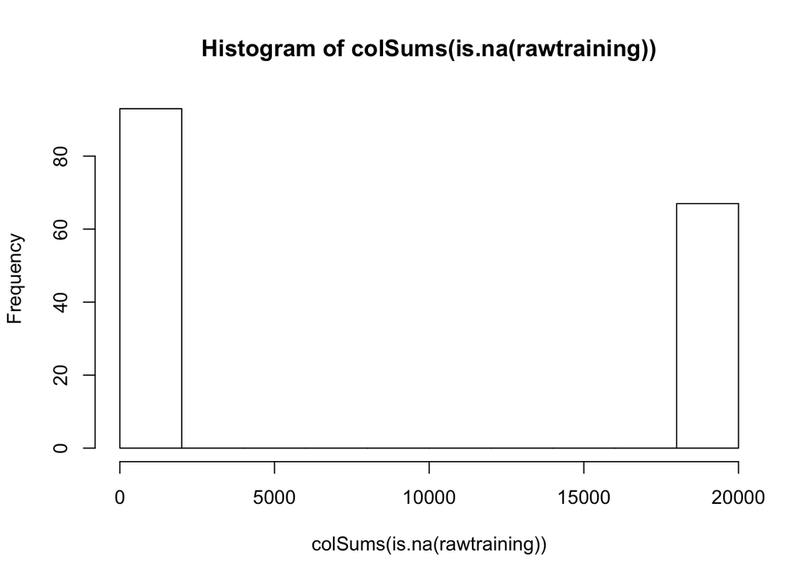

```r
hist(colSums(is.na(rawtraining)))
```

It seems that there are two distinct sets of variables: one with only 406 observations and one with all the observations. Let’s get rid of the first set of variables by filtering those that are not present for 97% of the observations.

```r
filter <- colSums(is.na(rawtraining)) < 0.97 * nrow(rawtraining)
training <- rawtraining[,filter]
testing <- rawtesting[,filter]
```

Next we remove another set of columns with irrelevant information for our purpose like timestamps for instance.

```r
toBeRemoved =  c("X", "user_name", "raw_timestamp_part_1", "raw_timestamp_part_2", "cvtd_timestamp", "new_window", "num_window")
training <- training[,!(names(training) %in% toBeRemoved)]
testing <- testing[,!(names(testing) %in% toBeRemoved)]
```

Lastly we remove the near zero covariates.

```r
library(caret)
nsv <- nearZeroVar(training, saveMetrics = T)
training <- training[, !nsv$nzv]
testing <- testing[, !nsv$nzv]
```

# Partition the training set to create a cross validation set

```r
inTrain = createDataPartition(training$classe, p = 0.7,list=FALSE)
training = training[ inTrain,]
validation = training[-inTrain,]
```

# Fit model

In the absence of background knowlegde about the subject matter, we select the Random Forest algorithm to train our model. We set the number of trees to fifty on purpose in order to limit the computing time.

```r
set.seed(123)
modFit <- train(classe ~ ., data=training,method="rf",ntree=50, proximity=TRUE)
```

```r
verification <- predict(modFit,validation)
confusionMatrix(verification,validation$classe)
```

```
## Confusion Matrix and Statistics
##
##           Reference
## Prediction    A    B    C    D    E
##          A 1201    0    0    0    0
##          B    0  756    0    0    0
##          C    0    0  720    0    0
##          D    0    0    0  686    0
##          E    0    0    0    0  769
##
## Overall Statistics
##
##                Accuracy : 1
##                  95% CI : (0.9991, 1)
##     No Information Rate : 0.2907
##     P-Value [Acc > NIR] : < 2.2e-16
##
##                   Kappa : 1
##  Mcnemar's Test P-Value : NA
##
## Statistics by Class:
##
##                      Class: A Class: B Class: C Class: D Class: E
## Sensitivity            1.0000    1.000   1.0000    1.000   1.0000
## Specificity            1.0000    1.000   1.0000    1.000   1.0000
## Pos Pred Value         1.0000    1.000   1.0000    1.000   1.0000
## Neg Pred Value         1.0000    1.000   1.0000    1.000   1.0000
## Prevalence             0.2907    0.183   0.1742    0.166   0.1861
## Detection Rate         0.2907    0.183   0.1742    0.166   0.1861
## Detection Prevalence   0.2907    0.183   0.1742    0.166   0.1861
## Balanced Accuracy      1.0000    1.000   1.0000    1.000   1.0000
```

```r
prediction <- predict(modFit,testing)
```

Lastly we create the files for the automated grading system.

```r
pml_write_files = function(x){
     n = length(x)
     for(i in 1:n){
         filename = paste0("problem_id_",i,".txt")
         write.table(x[i],file=filename,quote=FALSE,row.names=FALSE,col.names=FALSE)
     }
}

pml_write_files(prediction)
```